[figure not shown]

# TP1 : Introduction à git.

**Objectifs :**

- Configurer son repository git.
- Créer un compte github.
- Forker un repository github.
- Cloner un repository github.
- S'authentifier auprès de github.

## 1. Configurer git

Dans un premier temps, nous allons configurer git en indiquant votre nom et votre adresse mail afin que vous puissiez être identifié comme l'auteur des commits que vous allez faire.

Les options à changer sont :

- `user.name`
- `user.email`

Vous pouvez aussi indiquer votre éditeur préféré avec l'option `core.editor`.

```bash
Correction
git config --global user.name Elephorm
git config --global user.email formation-git@elephorm.com
git config core.editor atom
```

Un exemple de config se trouve dans le répertoire `docs` du projet.

Pour un exemple de config très complet, rendez vous [ici](https://gist.github.com/pksunkara/988716)

## 2. Créer un compte github

Github est un site web qui propose une interface web communautaire par dessus git. Github est gratuit pour les projets open source et simple à utiliser. Cela en fait un outil de référence pour les projets open source.

C'est l'outil que nous allons utiliser pour notre TP.

Créer un compte github en suivant les [instructions](https://github.com/).

[figure not shown]

Créer votre premier repository github, donnez lui le nom `test-git-elephorm.`

[figure not shown]

## 3. Forker le repository du TP.

Pour pouvoir continuer le TP, vous aurez besoin de forker le repository de base du TP.

Forker permet de faire une copie du repository github. Cela vous permet de travailler librement sur une version d'un repo, de pusher vos modifications sans affecter le repository principal.

Il est toujours préférable de se synchroniser régulièrement avec le serveur, afin d'avoir une sauvegarde toujours à jour, surtout si vous êtes seul à travailler dessus.

Pour cela, rendez vous [ici](https://github.com/Elephorm-tp-git/Realtime-Markdown-Viewer)

Cliquez sur le boutton en haut à droite.

[figure not shown]

## 4. Cloner le repository forké sur votre machine.

Pour cloner le repository, vous aurez besoin de récupérer l'adresse de ce dernier.

Vous pouvez la récupérer sur la page du projet :

[figure not shown]

Remarquez qu'il y a trois type d'adresses :

#### HTTPS

L'adresse **HTTPS** permet de communiquer avec github avec le protocole https. Elle constitue une bonne alternative à SSH, notamment lorsque le port SSH est bloqué sur votre machine.

#### Subversion

L'adresse **subversion** permet d'utiliser github avec le gestionnaire de version `subversion`, nous ne nous en préoccuperons pas.

#### SSH

L'adresse **SSH** permet d'utiliser github avec le protocole SSH, qui est plus sécurisé que le protocole https. Pour pouvoir l'utiliser vous devez générer une paire de clef ssh et l'ajouter à votre dépôt. C'est le protocole que nous recommandons, qui est notamment le plus rapide et le plus sécurisé.

Pour générer une paire de clef, suivez le tutoriel de github [ici](https://help.github.com/articles/generating-ssh-keys/)

## 5. Fonctionnement de l'application

### Dépendances

L'application est développée en [nodejs](https://nodejs.org). Pour plus d'informations cliquez sur le lien.

Elle a besoin du [node package manager](https://www.npmjs.com) pour installer les dépendances.

Vous devez avoir `nodejs` et `npm` installé sur votre machine. L'installeur de nodejs est présent [ici](https://nodejs.org/download/). Npm est installé avec node. Si vous voulez plus d'informations avec notamment une vidéo de présentation, c'est [ici](https://docs.npmjs.com/getting-started/installing-node).

1. Rentrer dans le répertoire : `cd Realtime-Markdown-Viewer`
2. Installer les dépendances : `npm install`
3. Lancez l'application : `npm run dev`
4. Allez à cette [url](http://localhost:8000)

Vous devez vous retrouver avec ceci comme écran :

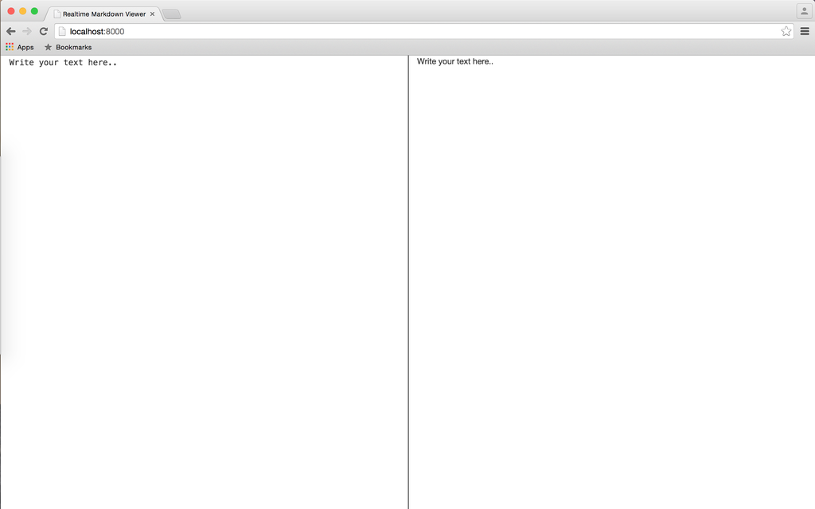

### Fonctionnement pour le TP.

Le répertoire qui nous intéresse est le répertoire `converter`. Vous n'aurez pas besoin de manipuler d'autres fichiers.

Ce dernier a la structure suivante :

- **markdown.js**
- tests/
  - markdown-test.js
  - **features/**
  - utils.js

Le fichier `markdown.js` contient le parser.

Le répertoire `features` contient un ensemble de fichiers markdown et html pour nos tests.

Lorsque nous ajoutons une fonctionnalité, nous l'accompagnerons d'un test afin de vérifier son bon fonctionnement. Pour ajouter un test il suffit d'ajouter un fichier markdown et un fichier html portant le même nom dans le répertoire `features`.

Pour lancer les tests, la commande à éxécuter à la racine du projet est :

```bash
npm run test
```

Revenez à cette [url](http://localhost:8000).

À gauche, vous avez le panel dans lequel vous pouvez écrire du markdown et à droite le rendu HTML.

Nous avons déjà développé une fonctionnalité pour vous. Le parsing des différents titres d'une page.

Essayer le code suivant dans le panel de gauche :

```bash
# Un grand titre
### Un plus petit titre
```

Vous devriez avoir le panel de droite qui se met à jour automatiquement.

Par contre si vous essayez d'écrire :

```bash
**Ce texte doit apparaitre en gras**
```

Vous pouvez voir que le texte n'est pas transformé.

Tout au cours de ce TP, nous allons ajouter des fonctionnalités à notre parser Markdown.

L'objectif du TP n'est pas de se concentrer sur le code du parser. Nous l'utilisons comme prétexte pour utiliser git. Toutes les réponses vous seront données au cours du TP.

Vous êtes maintenant prêt à faire votre premier commit. Rendez vous au TP2 !